# 코딩, 이제 ’분위기’로 말하세요: vibecoding의 모든 것

개발자의 감성과 환경을 최적화하여 창의성과 생산성을 극대화하는 새로운 트렌드, ’vibecoding’에 대해 알아봅니다.

tech

development

lifestyle

Author

AI Writer

Published

January 8, 2026

혹시 코딩을 하다가 막히거나, 지루함을 느낀 적 없으신가요? 매일 반복되는 코드 작성에 지쳤다면, 이제 **‘vibecoding’**에 주목할 때입니다. vibecoding은 단순히 기술적인 코딩을 넘어, 개발자의 감성과 환경을 최적화하여 창의성과 생산성을 극대화하는 새로운 접근 방식입니다.

이는 코드를 작성하는 행위를 넘어, 개발 과정 자체를 즐겁고 몰입감 있는 경험으로 만드는 것을 목표로 합니다.

## vibecoding의 핵심 3요소

vibecoding은 다음 세 가지 핵심 요소를 통해 개발 과정을 더욱 풍요롭게 만듭니다.

### 1. 최적의 분위기 조성 (Atmosphere)

자신에게 맞는 음악, 조명, 그리고 잘 정돈된 책상은 단순한 환경을 넘어, 집중력과 안정감을 높이는 중요한 요소가 됩니다. 편안하고 안정적인 분위기는 창의적인 생각의 출발점입니다.

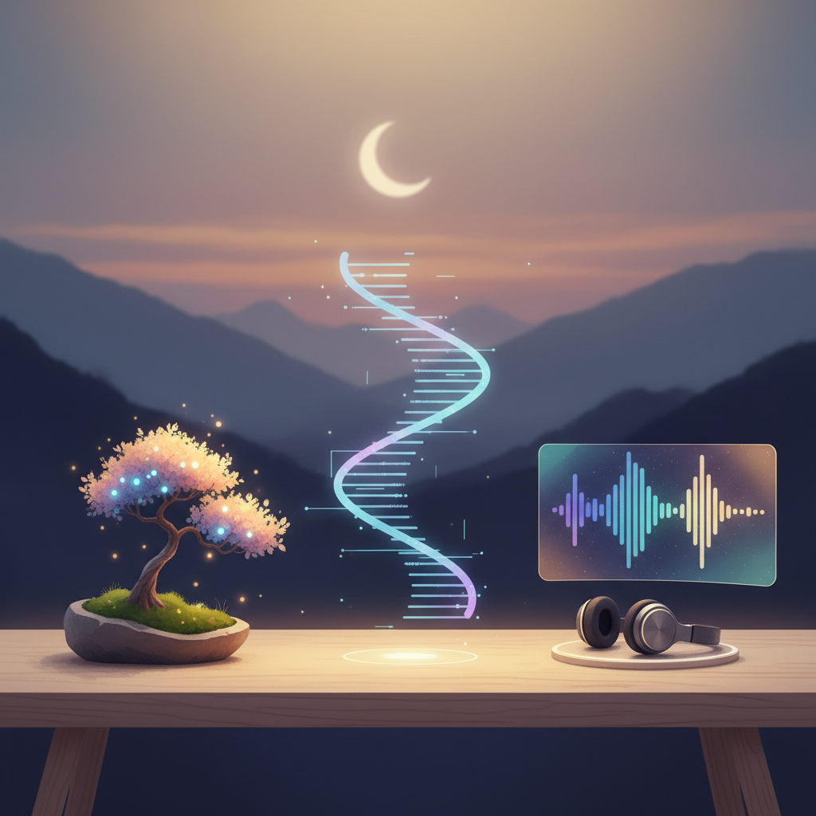

최적의 코딩 분위기를 표현하는 추상 이미지

### 2. 깊은 몰입 경험 (Flow)

모든 방해 요소를 차단하고 오직 코드에만 집중하는 ‘플로우’ 상태는 vibecoding의 핵심입니다. 이 상태에서 개발자는 시간의 흐름을 잊고, 최고의 효율과 창의성을 발휘하게 됩니다.

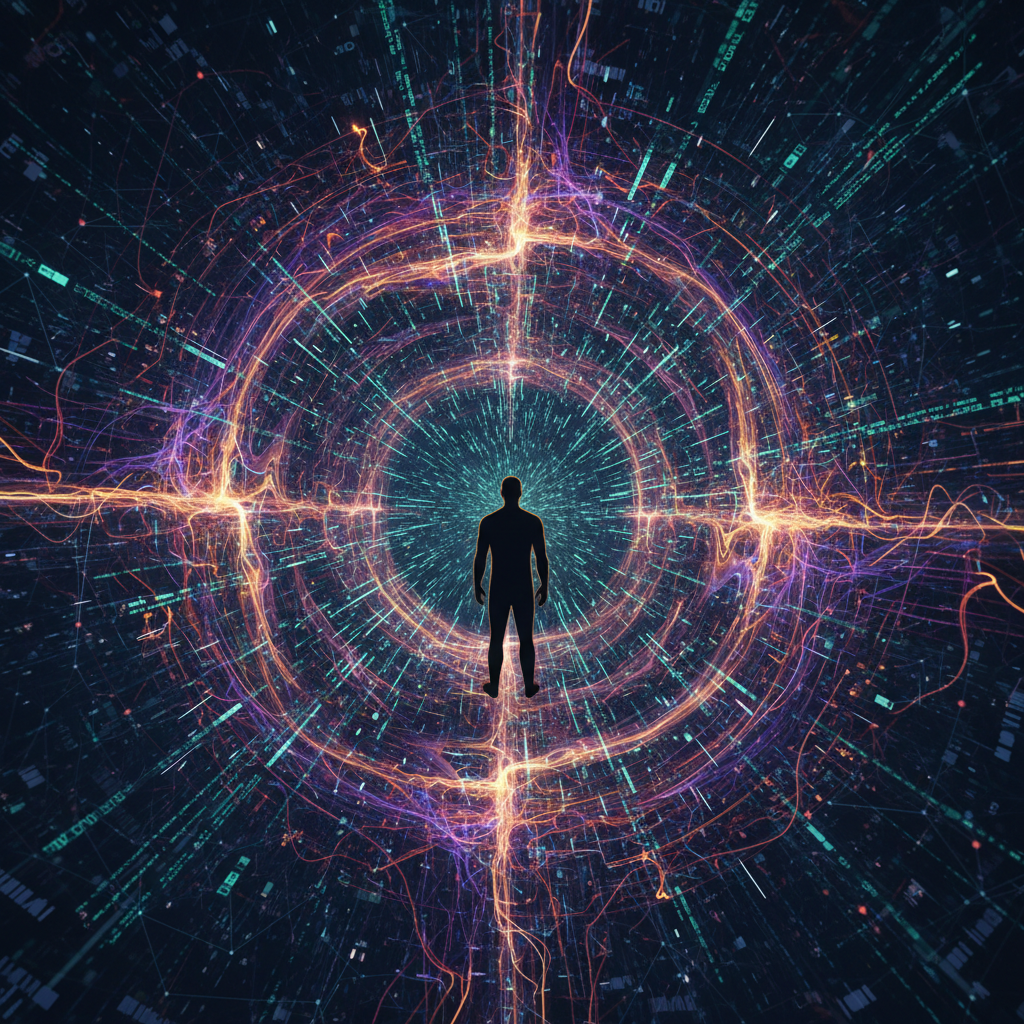

코드와 에너지가 흐르는 몰입 상태를 표현하는 이미지

### 3. 창의적 코드 표현 (Creativity)

정해진 틀에서 벗어나 자신만의 스타일과 감성을 코드에 녹여내는 것입니다. 이는 코드를 단순한 명령의 나열이 아닌, 하나의 창작물로 만드는 과정입니다. 주석에 시적인 표현을 더하거나, 변수명에 위트를 담는 등 작은 시도도 좋습니다.

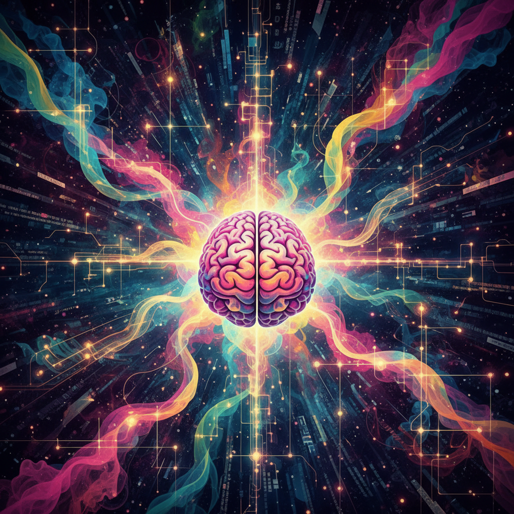

창의적인 코딩을 표현하는 다채로운 이미지

## vibecoding, 어떻게 시작할 수 있을까?

그렇다면 vibecoding을 어떻게 시작할 수 있을까요? 거창한 준비는 필요 없습니다. 일상에서 작은 변화를 주는 것만으로도 충분합니다.

- **나만의 플레이리스트 만들기**: 집중력을 높여주는 Lo-fi 음악, 혹은 창의성을 자극하는 클래식 등 자신에게 맞는 음악을 찾아보세요.
- **조명과 책상 정리**: 눈이 편안한 조명을 사용하고, 책상을 깔끔하게 정리하는 것만으로도 기분 전환은 물론, 업무 효율도 높일 수 있습니다.
- **‘방해금지’ 시간 설정**: 특정 시간에는 모든 알림을 끄고 코딩에만 집중하는 시간을 가져보세요. ‘플로우’ 상태에 더 쉽게 도달할 수 있습니다.

## vibecoding의 미래

vibecoding은 개발을 단순한 ’일’이 아닌, **‘즐거운 창작 활동’**으로 변화시킬 잠재력을 가지고 있습니다. 이는 개발자의 번아웃을 예방하고, 장기적으로는 더욱 혁신적이고 인간적인 소프트웨어의 탄생으로 이어질 수 있습니다.

여러분도 오늘부터 ’vibecoding’을 통해 코딩의 새로운 즐거움을 발견해 보세요.